# Exercise - some linear models part 1

Søren Højsgaard

*SOLUTION comment* This is a very rough suggested solution end of SOLUTION comment*

# 1 Introduction

The idea is to repeat what you saw in the lecture on linear models on another dataset.

```r
dat <- palmerpenguins::penguins
dat <- dat[complete.cases(dat),]
head(dat)
```

```
## # A tibble: 6 × 8
##   species island    bill_length_mm bill_depth_mm flipper_length_mm
##   <fct>   <fct>              <dbl>         <dbl>             <int>
## 1 Adelie  Torgersen           39.1          18.7               181
## 2 Adelie  Torgersen           39.5          17.4               186
## 3 Adelie  Torgersen           40.3          18                 195
## 4 Adelie  Torgersen           36.7          19.3               193
## 5 Adelie  Torgersen           39.3          20.6               190
## 6 Adelie  Torgersen           38.9          17.8               181
## # ℹ 3 more variables: body_mass_g <int>, sex <fct>, year <int>
```

```r
library(ggplot2)
library(broom)
```

We ask the following question:

1. How well can we predict the body mass of a penguin based on species and flipper length?
2. Are predictions improved by including other variables?

We encourage you to take inspiration from the lecture slides/notes.

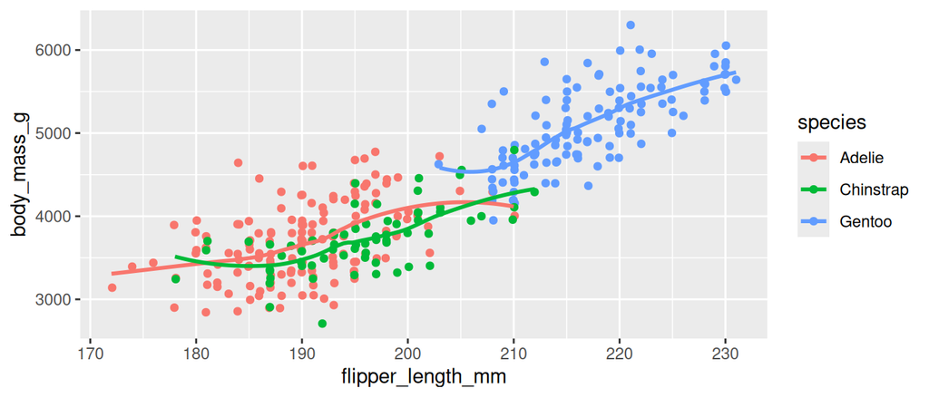

```r
pl0 <- dat |>
    ggplot(aes(x=flipper_length_mm, y=body_mass_g, color=species)) +
    geom_jitter(width=0.1)
pl0 + geom_smooth(se=FALSE)
```

# 2 Tasks

## 2.1 Task

Fit the following models to data and think carefully about their interpretation. Call the corresponding models `mm1`, `mm2`, `mm3`, and `mm4`.

```r
formula1 <- body_mass_g ~ flipper_length_mm
formula2 <- body_mass_g ~ species
formula3 <- body_mass_g ~ species + flipper_length_mm
formula4 <- body_mass_g ~ species * flipper_length_mm
```

```r
## YOUR CODE
```

```r
## SOLUTION
mm1 <- lm(body_mass_g ~ flipper_length_mm, data = dat)
mm2 <- lm(body_mass_g ~ species, data = dat)
mm3 <- lm(body_mass_g ~ species + flipper_length_mm, data = dat)
mm4 <- lm(body_mass_g ~ species * flipper_length_mm, data = dat)
```

## 2.2 Task

Use the `tidy` function in the `broom` package to get a nice summary of the models.

```r
## YOUR CODE
```

```r
## SOLUTION
mm1 |> tidy()
```

```
## # A tibble: 2 × 5
##   term              estimate std.error statistic   p.value
##   <chr>                <dbl>     <dbl>     <dbl>     <dbl>
## 1 (Intercept)        -5872.     310.       -18.9 1.18e- 54
## 2 flipper_length_mm     50.2      1.54      32.6 3.13e-105
```

```r
mm2 |> tidy()
```

```
## # A tibble: 3 × 5
##   term             estimate std.error statistic   p.value
##   <chr>               <dbl>     <dbl>     <dbl>     <dbl>
## 1 (Intercept)        3706.       38.1    97.2   6.88e-245
## 2 speciesChinstrap     26.9      67.7     0.398 6.91e-  1
## 3 speciesGentoo      1386.       56.9    24.4   1.01e- 75
```

```r
mm3 |> tidy()
```

```
## # A tibble: 4 × 5
##   term              estimate std.error statistic  p.value
##   <chr>                <dbl>     <dbl>     <dbl>    <dbl>
## 1 (Intercept)        -4013.     586.       -6.85 3.74e-11
## 2 speciesChinstrap    -205.      57.6      -3.57 4.14e- 4
## 3 speciesGentoo        285.      95.4       2.98 3.08e- 3
## 4 flipper_length_mm     40.6      3.08     13.2  3.64e-32
```

```r
mm4 |> tidy()
```

```
## # A tibble: 6 × 5
##   term                             estimate std.error statistic  p.value
##   <chr>                               <dbl>     <dbl>     <dbl>    <dbl>
## 1 (Intercept)                      -2508.      892.      -2.81  5.25e- 3
## 2 speciesChinstrap                  -529.     1525.      -0.347 7.29e- 1
## 3 speciesGentoo                    -4166.     1432.      -2.91  3.86e- 3
## 4 flipper_length_mm                   32.7       4.69     6.97  1.78e-11
## 5 speciesChinstrap:flipper_length…     1.88      7.86     0.240 8.11e- 1
## 6 speciesGentoo:flipper_length_mm     21.5       6.97     3.08  2.23e- 3
```

## 2.3 Task

1. Create plots of the fitted values on top of the data. Call these plots `pl1`, `pl2`, `pl3`, and `pl4`.

```r
## YOUR CODE
```

```r
## SOLUTION
pl1 <- pl0 + geom_line(aes(y=fitted(mm1)))
pl2 <- pl0 + geom_line(aes(y=fitted(mm2)))
pl3 <- pl0 + geom_line(aes(y=fitted(mm3)))
pl4 <- pl0 + geom_line(aes(y=fitted(mm4)))
```

Display the plots side by side with:

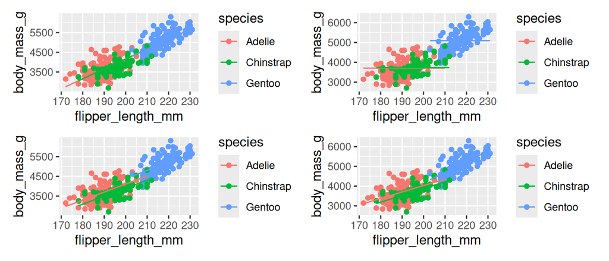

```r
library(patchwork)
(pl1 + pl2) / (pl3 + pl4)
```

Create a list of models along these lines:

```r
ml <- list(m1=mm1, m2=mm2, m3=mm3, m4=mm4)
```

## 2.4 Task

Use the `rmse` function in the `modelr` package to calculate the root mean squared error of the models on the data set.

```r
## YOUR CODE
```

```r
## SOLUTION
sapply(ml, function(x) modelr::rmse(x, dat))
```

```
##    m1    m2    m3    m4
## 392.2 458.7 371.0 365.1
```

## 2.5 Task

Split data randomly into a training dataset (with 80 pct of the observations) and a test dataset with the remaining observations. Set the seed as:

```r
set.seed(2024)
```

```r
## YOUR CODE
```

```r
## SOLUTION
i <- sample(nrow(dat), size=0.8*nrow(dat))
i |> head()
```

```
## [1]  66  37  45 188 255 109
```

```r
train <- dat[i,]
test <- dat[-i,]
```

## 2.6 Task

Refit the models on the training data and calculate the RMSE on the training and test data.

```r
## YOUR CODE
```

```r
## SOLUTION
ml_train <- sapply(ml, function(x) update(x, data=train))
sapply(ml_train, function(x) modelr::rmse(x, train))
```

```
##    m1    m2    m3    m4
## 395.3 465.1 372.4 367.2
```

```r
sapply(ml_train, function(x) modelr::rmse(x, test))
```

```
##    m1    m2    m3    m4
## 379.9 434.2 368.7 359.2
```

THE END !